# Portfolio assignment 6

```python
import pandas as pd
```

```python
songs = pd.read_csv('songs.csv', index_col='Unnamed: 0', quotechar="`")
```

## Algemeen

```python
songs
```

|  | Title | Artist | Genre | Year | BPM | Energy | Danceability | dB | Live | Valence | Duration | Acousticness | Speechiness | Popularity |
| --- | --- | --- | --- | --- | --- | --- | --- | --- | --- | --- | --- | --- | --- | --- |
| 1 | Hey, Soul Sister | Train | neo mellow | 2010 | 97 | 89 | 67 | -4 | 8 | 80 | 217 | 19 | 4 | 83 |
| 2 | Love The Way You Lie | Eminem | detroit hip hop | 2010 | 87 | 93 | 75 | -5 | 52 | 64 | 263 | 24 | 23 | 82 |
| 3 | TiK ToK | Kesha | dance pop | 2010 | 120 | 84 | 76 | -3 | 29 | 71 | 200 | 10 | 14 | 80 |
| 4 | Bad Romance | Lady Gaga | dance pop | 2010 | 119 | 92 | 70 | -4 | 8 | 71 | 295 | 0 | 4 | 79 |
| 5 | Just the Way You Are | Bruno Mars | pop | 2010 | 109 | 84 | 64 | -5 | 9 | 43 | 221 | 2 | 4 | 78 |
| ... | ... | ... | ... | ... | ... | ... | ... | ... | ... | ... | ... | ... | ... | ... |
| 599 | Find U Again (feat. Camila Cabello) | Mark Ronson | dance pop | 2019 | 104 | 66 | 61 | -7 | 20 | 16 | 176 | 1 | 3 | 75 |
| 600 | Cross Me (feat. Chance the Rapper & PnB Rock) | Ed Sheeran | pop | 2019 | 95 | 79 | 75 | -6 | 7 | 61 | 206 | 21 | 12 | 75 |
| 601 | No Brainer (feat. Justin Bieber, Chance the Ra... | DJ Khaled | dance pop | 2019 | 136 | 76 | 53 | -5 | 9 | 65 | 260 | 7 | 34 | 70 |
| 602 | Nothing Breaks Like a Heart (feat. Miley Cyrus) | Mark Ronson | dance pop | 2019 | 114 | 79 | 60 | -6 | 42 | 24 | 217 | 1 | 7 | 69 |
| 603 | Kills You Slowly | The Chainsmokers | electropop | 2019 | 150 | 44 | 70 | -9 | 13 | 23 | 213 | 6 | 6 | 67 |

603 rows × 14 columns

### Title

```python
songs.Title.unique()
```

```
array(['Hey, Soul Sister', 'Love The Way You Lie', 'TiK ToK',
       'Bad Romance', 'Just the Way You Are', 'Baby', 'Dynamite',
       'Secrets', 'Empire State of Mind (Part II) Broken Down',
       'Only Girl (In The World)',
       "Club Can't Handle Me (feat. David Guetta)", 'Marry You',
       'Cooler Than Me - Single Mix', 'Telephone', 'Like A G6',
       'OMG (feat. will.i.am)', 'Eenie Meenie', 'The Time (Dirty Bit)',
       'Alejandro', 'Your Love Is My Drug', 'Meet Me Halfway',
       'Whataya Want from Me', 'Take It Off', 'Misery',
       'All The Right Moves', 'Animal', 'Naturally', 'I Like It',
       'Teenage Dream', 'California Gurls', '3',
       'My First Kiss - feat. Ke$ha', 'Blah Blah Blah (feat. 3OH!3)',
       'Imma Be', 'Try Sleeping with a Broken Heart',
       'Sexy Bitch (feat. Akon)',
       'Bound To You - Burlesque Original Motion Picture Soundtrack',
       'If I Had You', 'Rock That Body', 'Dog Days Are Over',
       "Something's Got A Hold On Me - Burlesque Original Motion Picture Soundtrack",
       "Doesn't Mean Anything", 'Hard', 'Loca', 'You Lost Me',
       'Not Myself Tonight', 'Written in the Stars (feat. Eric Turner)',
       "DJ Got Us Fallin' In Love (feat. Pitbull)",
       'Castle Walls (feat. Christina Aguilera)', 'Break Your Heart',
       'Hello', 'A Thousand Years', 'Someone Like You',
       'Give Me Everything', 'Rolling in the Deep',
       'Run the World (Girls)',
       'Moves Like Jagger - Studio Recording From The Voice Performance',
       'Love On Top', 'Grenade', 'Tonight Tonight', 'What the Hell',
       'Born This Way', 'Monster', 'Best Thing I Never Had',
       'Party Rock Anthem', 'We R Who We R', 'Price Tag', 'Good Life',
       'Just Can’t Get Enough', 'On The Floor', "What's My Name?",
       'Yeah 3x', 'Without You (feat. Usher)', 'Sexy And I Know It',
       'The Edge Of Glory', 'E.T.', 'Till the World Ends', 'I Wanna Go',
       'Blow', 'You And I', 'Judas', "Tonight (I'm Fuckin' You)",
       "Please Don't Go", 'We Found Love', 'Marry The Night', '1+1',
       'Hold It Against Me', "I'm Into You", 'Papi',
       'Cheers (Drink To That)', 'S&M Remix', 'Jar of Hearts',
       'Turning Page', 'Super Bass', 'Raise Your Glass',
       'Invading My Mind', 'Moment 4 Life - Album Version (Edited)',
       'Last Friday Night (T.G.I.F.)', 'Firework',
       'Muny - Album Version (Edited)', 'Titanium (feat. Sia)',
       'Locked Out of Heaven', 'Paradise', 'Payphone',
```

[output cut: 179 more lines]

```
       'South of the Border (feat. Camila Cabello & Cardi B)',
       'Trampoline (with ZAYN)', 'Happier', 'Truth Hurts',
       'Good as Hell (feat. Ariana Grande) - Remix', 'Higher Love',
       'Only Human', 'Beautiful People (feat. Khalid)', 'Sucker',
       "Don't Call Me Up", "I Don't Care (with Justin Bieber)",
       'Talk (feat. Disclosure)', "Giant (with Rag'n'Bone Man)",
       'Takeaway', 'All Around The World (La La La)',
       'Girls Like You (feat. Cardi B)', 'Call You Mine',
       'No Guidance (feat. Drake)', 'Antisocial (with Travis Scott)',
       'Taki Taki (feat. Selena Gomez, Ozuna & Cardi B)',
       'Con Calma - Remix', 'Find U Again (feat. Camila Cabello)',
       'Cross Me (feat. Chance the Rapper & PnB Rock)',
       'No Brainer (feat. Justin Bieber, Chance the Rapper & Quavo)',
       'Nothing Breaks Like a Heart (feat. Miley Cyrus)',
       'Kills You Slowly'], dtype=object)
```

Deze lijst geeft alle unieke titels weer die zich in de tabel bevinden. Omdat er zoveel unieke waardes zijn heeft het geen extra waarde om hier een grafiek van te genereren, deze zal onoverzichtelijk en onleesbaar worden.

### Artist

```python
songs.Artist.unique()
```

```
array(['Train', 'Eminem', 'Kesha', 'Lady Gaga', 'Bruno Mars',
       'Justin Bieber', 'Taio Cruz', 'OneRepublic', 'Alicia Keys',
       'Rihanna', 'Flo Rida', 'Mike Posner', 'Far East Movement', 'Usher',
       'Sean Kingston', 'The Black Eyed Peas', 'Adam Lambert', 'Maroon 5',
       'Neon Trees', 'Selena Gomez & The Scene', 'Enrique Iglesias',
       'Katy Perry', 'Britney Spears', '3OH!3', 'David Guetta',
       'Christina Aguilera', 'Florence + The Machine', 'Shakira',
       'Tinie Tempah', 'T.I.', 'Martin Solveig', 'Christina Perri',
       'Adele', 'Pitbull', 'Beyoncé', 'Hot Chelle Rae', 'Avril Lavigne',
       'Kanye West', 'LMFAO', 'Jessie J', 'Jennifer Lopez', 'Chris Brown',
       'Sleeping At Last', 'Nicki Minaj', 'P!nk', 'Coldplay',
       'One Direction', 'Taylor Swift', 'Carly Rae Jepsen',
       'Kelly Clarkson', 'Owl City', 'The Wanted', 'fun.',
       'Ellie Goulding', 'Gym Class Heroes', 'Avicii', 'The Script',
       'Miley Cyrus', 'Swedish House Mafia', 'Daft Punk', 'James Arthur',
       'Robin Thicke', 'Demi Lovato', 'Zedd', 'Lana Del Rey',
       'Calvin Harris', 'Drake', 'Sara Bareilles',
       'Macklemore & Ryan Lewis', 'Labrinth', 'Ne-Yo', 'Ariana Grande',
       'Justin Timberlake', 'will.i.am', 'Icona Pop', 'Fergie',
       'Little Mix', 'Emeli Sandé', 'Selena Gomez', 'Austin Mahone',
       'Jonas Brothers', 'Mariah Carey', 'Ciara', 'Jewel',
       'Kelly Rowland', 'John Legend', 'Sam Smith', 'Pharrell Williams',
       'MAGIC!', 'Passenger', 'Bastille', 'Lorde', 'John Newman',
       'Disclosure', 'Michael Jackson', '5 Seconds of Summer',
       'Iggy Azalea', 'Jason Derulo', 'The Chainsmokers', 'Birdy',
       'A Great Big World', 'Sia', 'Charli XCX', 'Lily Allen',
       'Lea Michele', 'Ed Sheeran', 'The Weeknd', 'Mark Ronson', 'Hozier',
       'Shawn Mendes', 'Mr. Probz', 'Zara Larsson', 'Fifth Harmony',
       'Clean Bandit', 'Meghan Trainor', 'Nick Jonas', 'Paloma Faith',
       'Olly Murs', 'Naughty Boy', 'Alessia Cara', 'Sigala', 'Rudimental',
       'Lost Frequencies', 'Robin Schulz', 'Lilly Wood and The Prick',
       'Wiz Khalifa', 'Alesso', 'Madonna', 'Gwen Stefani', 'Jess Glynne',
       'Hilary Duff', 'Ricky Martin', 'Jennifer Hudson', 'DNCE',
       'Martin Garrix', 'Lukas Graham', 'G-Eazy', 'Hailee Steinfeld',
       'BØRNS', 'Major Lazer', 'MØ', 'Tove Lo', 'ZAYN', 'Bebe Rexha',
       'Snakehips', 'Missy Elliott', 'Years & Years', 'Charlie Puth',
       'Janet Jackson', 'Joey Montana', 'Nelly Furtado', 'DJ Snake',
       'Kygo', 'DJ Khaled', 'Luis Fonsi', 'Camila Cabello', 'Jonas Blue',
       'CNCO', 'Cardi B', 'Alan Walker', 'Liam Payne', 'Niall Horan',
       'Cashmere Cat', 'Galantis', 'Dua Lipa', 'Silk City', 'Marshmello',
       'Halsey', 'Troye Sivan', 'Dan + Shay', 'Rita Ora', 'Harry Styles',
       'Ansel Elgort', 'J Balvin', 'N.E.R.D', 'Hayley Kiyoko', 'RedOne',
       'Lewis Capaldi', 'SHAED', 'Lizzo', 'Mabel', 'Khalid', 'R3HAB',
       'Daddy Yankee'], dtype=object)
```

```python
songs['Artist'].value_counts(dropna=False).head(10)
```

```
Katy Perry          17
Justin Bieber       16
Rihanna             15
Maroon 5            15
Lady Gaga           14
Bruno Mars          13
Shawn Mendes        11
Pitbull             11
Ed Sheeran          11
The Chainsmokers    11
Name: Artist, dtype: int64
```

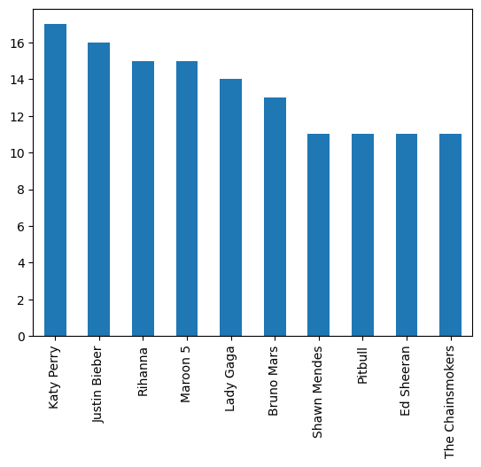

```python
songs['Artist'].value_counts(dropna=False).head(10).plot(kind='bar')
```

Er staan vele artiesten in deze tabel, omdat er wel een aantal artiesten meerdere keren voorkomen kan er geteld worden hoevaak een artiestnaam in de tabel staat om te kijken welke 10 artiesten het meeste voorkomen. Deze informatie is vervolgens weergegeven in een staafdiagram om een overzichtelijk diagram te behouden.

### Genre

```python
songs['Genre'].unique()
```

```
array(['neo mellow', 'detroit hip hop', 'dance pop', 'pop',
       'canadian pop', 'hip pop', 'barbadian pop', 'atl hip hop',
       'australian pop', 'indie pop', 'art pop', 'colombian pop',
       'big room', 'british soul', 'chicago rap', 'acoustic pop',
       'permanent wave', 'boy band', 'baroque pop', 'celtic rock',
       'electro', 'complextro', 'canadian hip hop', 'candy pop',
       'alaska indie', 'folk-pop', 'metropopolis', 'house',
       'australian hip hop', 'electropop', 'australian dance',
       'hollywood', 'canadian contemporary r&b',
       'irish singer-songwriter', 'tropical house', 'belgian edm',
       'french indie pop', 'hip hop', 'danish pop', 'latin',
       'canadian latin', 'electronic trap', 'edm', 'electro house',
       'downtempo', 'brostep', 'contemporary country', 'moroccan pop',
       'escape room', 'alternative r&b'], dtype=object)
```

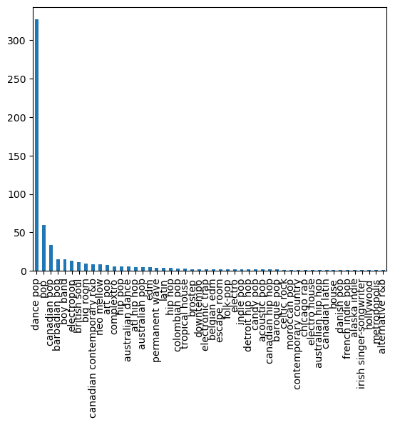

```python
songs['Genre'].value_counts(dropna=False).plot(kind='bar')
```

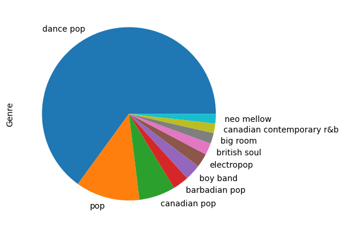

```python
songs['Genre'].value_counts(dropna=False).head(10).plot(kind='pie')
```

Er is in bovenstaand cirkeldiagram een selectie gemaakt van de top 10 meest voorkomende genres. Omdat er vele unieke genres zijn en het een onoverzichtelijk diagram zou worden is er een count gedaan op de genres en de top 10 weergegeven.

### Year

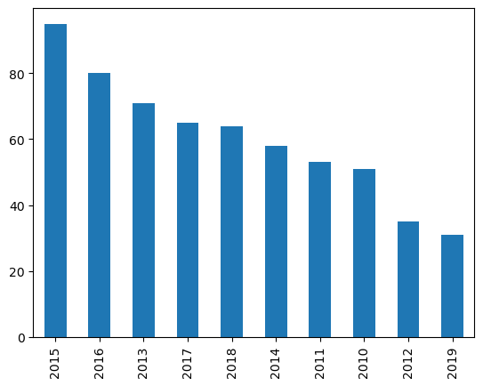

```python
songs['Year'].value_counts(dropna=False).plot(kind='bar')
```

### Numerieke waardes

```python
songs.describe()
```

|  | Year | BPM | Energy | Danceability | dB | Live | Valence | Duration | Acousticness | Speechiness | Popularity |
| --- | --- | --- | --- | --- | --- | --- | --- | --- | --- | --- | --- |
| count | 603.000000 | 603.000000 | 603.000000 | 603.000000 | 603.000000 | 603.000000 | 603.000000 | 603.000000 | 603.000000 | 603.000000 | 603.000000 |
| mean | 2014.592040 | 118.545605 | 70.504146 | 64.379768 | -5.578773 | 17.774461 | 52.225539 | 224.674959 | 14.326700 | 8.358209 | 66.520730 |
| std | 2.607057 | 24.795358 | 16.310664 | 13.378718 | 2.798020 | 13.102543 | 22.513020 | 34.130059 | 20.766165 | 7.483162 | 14.517746 |
| min | 2010.000000 | 0.000000 | 0.000000 | 0.000000 | -60.000000 | 0.000000 | 0.000000 | 134.000000 | 0.000000 | 0.000000 | 0.000000 |
| 25% | 2013.000000 | 100.000000 | 61.000000 | 57.000000 | -6.000000 | 9.000000 | 35.000000 | 202.000000 | 2.000000 | 4.000000 | 60.000000 |
| 50% | 2015.000000 | 120.000000 | 74.000000 | 66.000000 | -5.000000 | 12.000000 | 52.000000 | 221.000000 | 6.000000 | 5.000000 | 69.000000 |
| 75% | 2017.000000 | 129.000000 | 82.000000 | 73.000000 | -4.000000 | 24.000000 | 69.000000 | 239.500000 | 17.000000 | 9.000000 | 76.000000 |
| max | 2019.000000 | 206.000000 | 98.000000 | 97.000000 | -2.000000 | 74.000000 | 98.000000 | 424.000000 | 99.000000 | 48.000000 | 99.000000 |

### dB

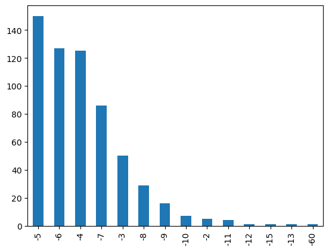

```python
songs['dB'].value_counts(dropna=False).plot(kind='bar')
```

Alle numerieke waardes zijn continue, behalve het aantal dB. Dit is ook de reden waarom deze waarde als enige overzichtelijk weergegeven kan worden. Zoals in het bovenstaande staafdiagram te zien is zijn er 140+ liedjes met een geluid van -5 dB. Dit is dan ook de meest voorkomende waarde.

### BPM

```python
songs['BPM'].unique()
```

```
array([ 97,  87, 120, 119, 109,  65, 148,  93, 126, 128, 145, 130, 122,
       125, 121,  99, 186, 103, 146, 133, 129, 135, 138,  92, 111, 164,
       131, 150, 104, 182, 112,  43,  91,  80, 139, 105, 127,  94, 110,
       100, 124, 175,  95, 152, 132,  63,  84,  75,  98, 144, 140,  77,
       117, 108,  86, 116, 160, 134, 184,  90, 114,  85, 180, 170, 174,
       155, 118, 185, 136,  82, 102, 107, 201,  96,  83, 192,  76, 149,
        79, 113, 115, 206, 190, 158, 176, 123, 106,  78, 156,  89, 202,
       142, 163, 101,   0, 159,  81,  73, 178, 181, 167, 172,  88, 168],
      dtype=int64)
```

Omdat er van de BPM kolom zoveel verschillende unieke waardes zijn, is het niet handig om hier een grafiek van te maken. Dit word namelijk niet overzichtelijk en geeft ons geen verdere informatie. Wat er wel gemaakt kan worden is een histogram en een boxplot.